# Supplementary Statistical Analysis

# 7 Split Data Models

It was hypothesised that the parameters influencing the planning acceptance of wind energy may vary between countries within Great Britain. England, Scotland and Wales have varying demographics and population densities as well as differing institutional support from national governments, with Scotland placing a greater emphasis on the development of onshore wind. It can also be seen that existing planning acceptance rates are lower in England than in Scotland and Wales. However, the global model presented was not able to account for any regional variation in relationships.

Where significant variation is expected within subgroups, split data models are recommended, whereby the dataset was segmented into groups based on model variables, and regression models were fitted to each subgroup. Whilst a dummy variable could also be considered, such an approach only captures the *level* effect and not the *slope* effect, and therefore only allows for limited variability between the subgroups. A split data approach was therefore developed using the Country variable, creating three separate models for England, Scotland and Wales respectively.

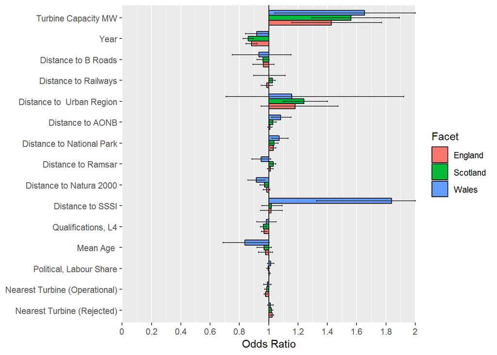

```r
segmented_country$plot
```

```r
# Make a segmented table
england <- WindAnalysis::LogisticResultsTable(segmented_country$models$England) %>%
    dplyr::select(c("Variable", "Odds Ratio", "Sig."))
scotland <- WindAnalysis::LogisticResultsTable(segmented_country$models$Scotland) %>%
    dplyr::select(c("Odds Ratio", "Sig."))
wales <- WindAnalysis::LogisticResultsTable(segmented_country$models$Wales) %>%
    dplyr::select(c("Odds Ratio", "Sig."))

segmented <- bind_cols(england, scotland, wales) %>% set_names(c("Variable",
    rep(c("OR", ""), 3)))

segmented$Variable <- matchNames(segmented$Variable)

knitr::kable(segmented)
```

| Variable | OR |  | OR |  | OR |  |
| --- | --- | --- | --- | --- | --- | --- |
| Turbine Capacity MW | 1.428 | *** | 1.562 | *** | 1.654 | * |
| Year | 0.882 | *** | 0.859 | *** | 0.919 | * |
| Distance to B Roads | 0.962 |  | 0.961 | . | 0.933 |  |
| Distance to Railways | 0.987 |  | 1.027 | ** | 1.001 |  |
| Distance to Urban Region | 1.181 |  | 1.240 | *** | 1.158 |  |
| Distance to AONB | 1.009 |  | 1.029 | ** | 1.083 | ** |
| Distance to National Park | 1.032 | *** | 1.036 | ** | 1.073 | ** |
| Distance to Ramsar | 1.012 |  | 1.030 | *** | 0.948 |  |
| Distance to Natura 2000 | 0.986 |  | 0.970 | * | 0.916 | ** |
| Distance to SSSI | 1.016 |  | 1.020 |  | 1.840 | *** |
| Qualifications, L4 | 0.969 | *** | 0.964 | ** | 0.984 |  |
| Mean Age | 0.978 |  | 0.969 |  | 0.836 | . |
| Political, Labour Share | 1.005 |  | 0.996 |  | 1.014 |  |
| Nearest Turbine (Operational) | 0.979 | *** | 0.987 | * | 0.991 |  |
| Nearest Turbine (Rejected) | 1.024 | *** | 1.019 | *** | 1.012 |  |

# 8 Prediciting Site Suitability

```r
# Load the directory of rasters These can be downloaded here:
rasters_dir <- "C:/Rasters"

# Extract parameters from model
raster_names <- variables_pars[!variables_pars %in% c("Turbine.Capacity..MW.",
    "year")] %>% paste0(., ".tif")

# Build a raster stack
raster_list <- LoadRaster(dir = rasters_dir, raster_names, message = FALSE)
raster_stack <- raster::stack(raster_list)
rm(raster_list)
```

Spatial prediction is conducted:

```r
# Although there is a function designed for this purpose, it has issues
# working with the logistic regression model built for this analysis. A more
# manual approach was therefore used, converting the raster to an XY data
# table as follows
grid_values <- rasterToPoints(raster_stack) %>% as.data.frame() %>% .[complete.cases(.),
    ]
grid_values$year <- 2015
grid_values$Turbine.Capacity..MW. <- 2
grid_values$Predicted <- predict.glm(object = model_pars, grid_values, type = "response")  # Calculate predicted values

# Converted prediction into raster and reproject
raster_predicted <- grid_values[, c(1, 2, ncol(grid_values))]  # Summarise dataset into XYZ table
raster_predicted <- suppressWarnings(raster::rasterFromXYZ(raster_predicted))
crs(raster_predicted) <- crs(raster_stack)

# Realign extents and add Predicted raster to stack
raster_stack <- crop(raster_stack, raster_predicted)
raster_stack <- stack(raster_predicted, raster_stack)
rm(raster_stack)

writeRaster(raster_predicted, "outputs/PredictedRaster.tif", overwrite = TRUE)
```

# 9 Finish

Some R objects are saved to the file to allow them to be access by the full report.

```r
# save tables for report
write.csv(model_results, file = "tables/modelResults.csv")

save(segmented, segmented_country, summary_split_model, model_pars, wind_models,
    model_pars_Summary, model_results, fullResultsTable, OddsPlotPars, file = "outputs/codeOutputs.RData")
```

# Bibliography

“A Comparison of Six Methods for Missing Data Imputation.” 2015. *Journal of Biometrics & Biostatistics* 06 (01): 1–6. doi:10.4172/2155-6180.1000224.

Allaire, JJ, Yihui Xie, Jonathan McPherson, Javier Luraschi, Kevin Ushey, Aron Atkins, Hadley Wickham, Joe Cheng, and Winston Chang. 2018. *Rmarkdown: Dynamic Documents for R*. https://CRAN.R-project.org/package=rmarkdown.

Civil Aviation Authority. 2016. “CAA Policy and Guidelines on Wind Turbines,” 1–45. http://www.caa.co.uk/docs/33/cap764.pdf.

Eltham, Douglas C., Gareth P. Harrison, and Simon J. Allen. 2008. “Change in public attitudes towards a Cornish wind farm: Implications for planning.” *Energy Policy* 36 (1): 23–33. doi:10.1016/j.enpol.2007.09.010.

Griffith, Daniel a. 2003. “Using Estimated Missing Spatial Data with the 2-Median Model.” *Annals of Operations Research* 122 (1-4): 233–47. doi:10.1023/A:1026106825798.

Harper, Michael. 2018. *WindAnalysis: Modelling Wind Turbine Acceptance Rates.*

Harrell, Frank E. 2001. *Regression modeling strategies. With applications to linear models, logistic regression, and survival analysis*. doi:10.1007/978-1-4757-3462-1.

Hosmer, David W, and Stanley Lemeshow. 2004. *Applied Logistic Regression Second Edition*. doi:10.1002/0471722146.

Rensburg, Thomas M. van, Hugh Kelley, and Nadine Jeserich. 2015. “What influences the probability of wind farm planning approval: Evidence from Ireland.” *Ecological Economics* 111. Elsevier B.V.: 12–22. doi:10.1016/j.ecolecon.2014.12.012.

Scottish Government. 2008. “Pan 45.”

[^1]: See https://goo.gl/mUA7QL for the planning decision documentation
[^2]: Note: the graph uses the censored datasets as described within this chapter. Individual observations are shown in the rug plots which highlight the marginal distributions
[^3]: A parsimonious model is a model that accomplishes a desired level of explanation or prediction with as few predictor variables as possible